# Assignment 2

David Utassy

2021 02 09

## Introduction

The purpose of this writing is to document the second assignment for the course Data Analysis 3 course.

The task was to build a model to predict the fast growth of firms. To put this into context the final prediction model of this project can serve a company investing in firms. The aim could be to find potential firms that will grow significantly in the future.

The whole analysis was written in R, and the code is available under this [GitHub repository](https://github.com/utassydv/data_analysis_prediction/tree/main/fast_growing_firms). We can separate the code into three parts. I prepared the data mainly in the “fast-growing-firm-data-prep.R” file, then the analysis and model building is done in the “fast-growing-firm-predicting.R” file, and the “fast-growing-firm-doc.Rmd” file is responsible for creating this document itself.

## Data

This project is similar to the case study in CH. 17. [Data Analysis for Business, Economics, and Policy, Gabor Bekes and Gabor Kezdi](https://gabors-data-analysis.com/).

The project uses the bisnode-firms dataset, which was collected, maintained, and cleaned by Bisnode, a major European business information company. The authors of the mentioned book cleaned and combined this dataset into one single work file which is an xt panel at the company-year level. I used [this workfile](https://osf.io/b2ft9/) as the input of my project.

#### Variables and Data preparation

As feature engineering and data preparation, I made similar decisions on predictor variables as the case study. Namely, I created ratios from financial variables, winsorized tails, added marker flags on the related observation, and applied some imputation.

In order to build a prediction model on the fast growth of firms, I needed to design a target variable that indicates whether a firm will have fast growth in the future or not.

The dataset contained information about firms between 2005 and 2016. I made the decision to build my model on variables from 2012, and consider a firm fast-growing if its growth is above 50% in 2014. The interval can be different (1-3 years) according to the business decision of the investing firm I work for with this project.

To define which firms are considered as “fast-growing”, we should define the term growth of course. In the end, I decided to observe the growth of the number of sales and define my target variable out of the percentage change of that.

It is important to note here, that I indicated the target variable from the sales_change(t+2), therefore, I cannot use that one as a predictor as it is information from the future, that I try to predict, however, it is still possible to include sales_change(t-1) or sales_change(t-2).

This has the following advantages:

Considering percentage changes avoids the effect of the absolute values of the variables By only using one variable (yearly number of sales) my logic is simple and easy to understand

On the other hand, I considered other alternatives as well, as the growth of a firm can be measured in different variables as well. First of all, in further improvement of this model, I might worth including any kind of asset growth into the target variable generation, as it should be a good indicator as well. On the other hand, I considered using profit growth, but that could be affected by the investment of the observed company in a negative direction. In the end, I believe that as a starting point, it is a good decision to go on with simple logic and improve it later if needed.

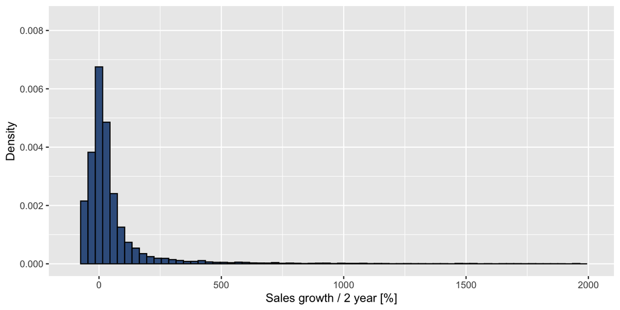

## Model Building for probability prediction

In order to get a great final model, and to learn the most from this project I evaluated seven different models. Five logit models with differently defined complexity in the sense of the number of predictor variables, a logit model with LASSO variable selection, and a Random Forest model 36 predictor variables.

The number of predictor variables is the same as in the case study. In the first model, we only have few variables picked by hand. The number of predictors grows until model number 4, where we have all the possible variables included, but no interactions. In the fifth logit model, we have some predefined interactions as well, so as in the variables provided for the LASSO algorithm. For the Random Forest model, I have provided all the raw variables without any interactions or modifications, that is why I have fewer predictors there.

#### Probability periction

At this point, all the models are good for predicting the probability of being a fast-growing firm. For training the models I used 5 fold cross-validation on the train data set with the same folds in order to be able to compare them. The comparison can be made by using the average RMSE over the folds. Also, we can compare the AUC of each model by calculating the ROC curves. In the table below, we can see the 7 models with these measures.

| Model | Number of predictors | CV RMSE | CV AUC |
| --- | --- | --- | --- |
| Logit M1 | 11 | 0.404 | 0.592 |
| Logit M2 | 18 | 0.399 | 0.635 |
| Logit M3 | 35 | 0.397 | 0.650 |
| Logit M4 | 79 | 0.396 | 0.655 |
| Logit M5 | 153 | 0.396 | 0.657 |
| Logit LASSO | 106 | 0.395 | 0.634 |
| RF Probability | 36 | 0.394 | 0.660 |

## Model selection for probability selection

From the table, we can see, that according to the RMSE of predicted probabilities and the AUC the Random Forest model is the best. It is interesting, however, that the Logit LASSO model has a small RMSE but with the AUC it has only the sixth rank.

According to these results, I would choose the random forest model for probability prediction, however, if the interpretation is important then I would go with Logit M5 or M4 as their results are just slightly worst.

## Classification

In order to predict whether a firm will grow fast or not, I have to choose a threshold at each model to classify the prediction. For choosing an optimal threshold I need a loss-function, which defines the loss by making false negative or false positive mistakes.

In my case, false-positive is the case, when the model predicts that the firm will grow fast, however in fact it is not. While the false-negative case is when to model predicts that the firm will not grow fast, however in fact it will.

Assume, that the company I make the model for is investing 10 million dollars into firms. In the false positive case, the investment does not have a profit. If we assume, that 20% percent of the firms go out of business, we can say, that on average, we will lose 2 million dollars. In the false-negative case, our company misses the profit that was there with an investment. As I defined a firm fast-growing if the sales grow by 50%, let’s say, that we are missing a 50% profit which is 5 million dollars.

Therefore the variables I need for the loss function are FP=2, FN=5.

By minimizing the loss function with each model I have an optimal threshold value and an expected loss with each model. In the following table, the reader can observe the models with these measures.

| Model | Number of predictors | CV RMSE | CV AUC | CV threshold | CV expected Loss |
| --- | --- | --- | --- | --- | --- |
| Logit M1 | 11 | 0.404 | 0.592 | 0.295 | 1.011 |
| Logit M2 | 18 | 0.399 | 0.635 | 0.283 | 0.947 |
| Logit M3 | 35 | 0.397 | 0.650 | 0.293 | 0.924 |
| Logit M4 | 79 | 0.396 | 0.655 | 0.293 | 0.915 |
| Logit M5 | 153 | 0.396 | 0.657 | 0.310 | 0.921 |
| Logit LASSO | 106 | 0.395 | 0.634 | 0.295 | 0.963 |
| RF Probability | 36 | 0.394 | 0.660 | 0.298 | 0.915 |

## Evaluation

In the table, it can be seen, that the Random Forest is still the best regarding the cross-validated expected loss, but Logit M4 has the same result. Remember Logit M4 is the model with all the variables (some of them are transformed) without interactions. From these results, I would still choose the Random Forest model if the goal is pure prediction, as it had the best results at every point. However this proves, the Logit M4 model is a great alternative if we need an interpretable model that has similar results.

Also, we can see, that the Logit Lasso model is still 6th, meaning, that the above mentioned AUC was a better measure than RMSE in this case.

For evaluation of the Random Forest model below, I show the calibration plot on the holdout dataset. From that, we can see, that our model is well-calibrated, as our predictions are around the 45-degree line.

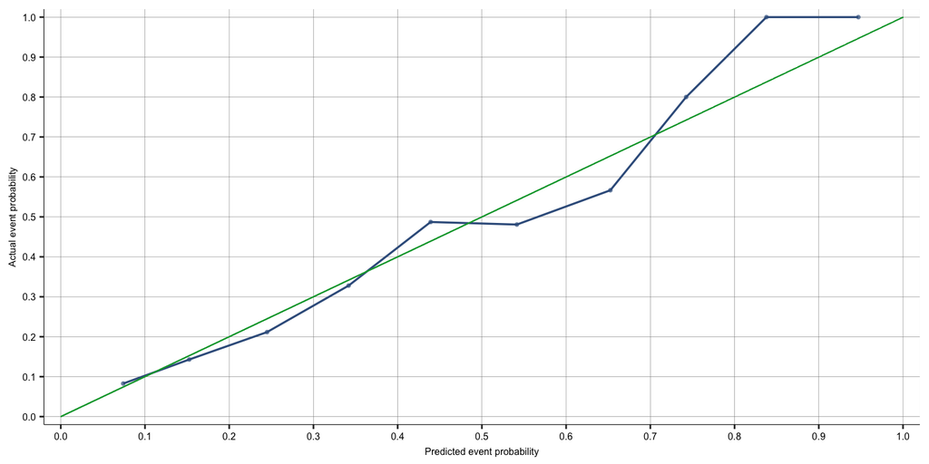

To show the performance of the model, it is an excellent way to show the confusion matrix (below) of the model on the holdout dataset.

| Model | not_fast_growing | fast_growing |
| --- | --- | --- |
| not_fast_growing | 2536 | 486 |
| fast_growing | 470 | 314 |

Of course, this confusion matrix is totally depending on the defined loss function. My model is trying to avoid making false-negative errors as the loss function penalizes those more. The accuracy of the model is about 75%, where the false-positive rate is 60% and the false-negative rate is only 16%.

## Summary

As the goal of this project was to predict whether observed firms are going to grow fast or not, it is a good practice to summarise the usefulness of the model from this point of view. If a company uses this model to make an investment decision with it, then it is a crucial point to have the loss-function well defined according to the business question. This should be lead according to financial reasons in order to create a valuable model. The same thing is true for the definition of the target variable. Both of these decisions need domain knowledge in the area where we are applying such a model.

However, according to the assumptions I made when making those decisions, the precision of the model looks OK, and it can be easily modified according to further decisions if needed.